# Prediction Based on Betting Markets

Earlier in the chapter, we studied the prediction of election outcomes using polls. Here, we study the prediction of election outcomes based on betting markets. In particular, we analyze data for the 2008 and 2012 US presidential elections from the online betting company, called Intrade. At Intrade, people trade contracts such as ‘Obama to win the electoral votes of Florida.’ Each contract’s market price fluctuates based on its sales. Why might we expect betting markets like Intrade to accurately predict the outcomes of elections or of other events? Some argue that the market can aggregate available information efficiently. In this exercise, we will test this *efficient market hypothesis* by analyzing the market prices of contracts for Democratic and Republican nominees’ victories in each state.

The data files for 2008 and 2012 are available in CSV format as `intrade08.csv` and `intrade12.csv`, respectively. The variables in these datasets are:

| Name | Description |
| --- | --- |
| `day` | Date of the session |
| `statename` | Full name of each state (including District of Columbia in 2008) |
| `state` | Abbreviation of each state (including District of Columbia in 2008) |
| `PriceD` | Closing price (predicted vote share) of Democratic Nominee’s market |
| `PriceR` | Closing price (predicted vote share) of Republican Nominee’s market |
| `VolumeD` | Total session trades of Democratic Party Nominee’s market |
| `VolumeR` m | Total session trades of Republican Party Nominee’s arket |

Each row represents daily trading information about the contracts for either the Democratic or Republican Party nominee’s victory in a particular state.

We will also use the election outcome data. These data files are `pres08.csv` and `pres12.csv` with variables:

| Name | Description |
| --- | --- |
| `state.name` | Full name of state (only in `pres2008`) |
| `state` | Two letter state abbreviation |
| `Obama` | Vote percentage for Obama |
| `McCain` | Vote percentage for McCain |
| `EV` | Number of electoral college votes for this state |

We’ll also use poll data from 2008 and 2012 in the files `polls08.csv` and `polls12.csv`, The variables in the polling data are:

| Name | Description |
| --- | --- |
| `state` | Abbreviated name of state in which poll was conducted |
| `Obama` | Predicted support for Obama (percentage) |
| `Romney` | Predicted support for Romney (percentage) |
| `Pollster` | Name of organization conducting poll |
| `middate` | Middle of the period when poll was conducted |

## Question 1

We will begin by using the market prices on the day before the election to predict the 2008 election outcome. To do this, subset the data such that it contains the market information for each state and candidate only on the day before the election. Note that in 2008 the election day was November 4. We compare the closing prices for the two candidates in a given state and classify a candidate whose contract has a higher price as the predicted winner of that state. Which states were misclassified? How does this compare to the classification by polls presented earlier in this chapter? Repeat the same analysis for the 2012 election, which was held on November 6. How well did the prediction market do in 2012 compared to 2008? Note that in 2012 some less competitive states have missing data on the day before the election because there were no trades on the Republican and Democratic betting markets. Assume Intrade predictions would have been accurate for these states.

## Answer 1

```r
intrade08 <- read.csv("intrade08.csv")
pres08<- read.csv("pres08.csv")
elections08 <- merge(pres08, intrade08, by ="state")
summary(elections08)
```

```
##     state            state.name            Obama           McCain
##  Length:36891       Length:36891       Min.   :33.00   Min.   : 7.00
##  Class :character   Class :character   1st Qu.:43.00   1st Qu.:40.00
##  Mode  :character   Mode  :character   Median :51.00   Median :47.00
##                                        Mean   :51.37   Mean   :47.06
##                                        3rd Qu.:58.00   3rd Qu.:56.00
##                                        Max.   :92.00   Max.   :66.00
##        EV            day             statename             PriceD
##  Min.   : 3.00   Length:36891       Length:36891       Min.   : 0.00
##  1st Qu.: 4.00   Class :character   Class :character   1st Qu.:12.50
##  Median : 8.00   Mode  :character   Mode  :character   Median :43.00
##  Mean   :10.55                                         Mean   :46.78
##  3rd Qu.:12.00                                         3rd Qu.:82.50
##  Max.   :55.00                                         Max.   :99.90
##     VolumeD            PriceR         VolumeR
##  Min.   :    0.0   Min.   : 0.00   Min.   :    0.000
##  1st Qu.:    0.0   1st Qu.:15.20   1st Qu.:    0.000
##  Median :    0.0   Median :51.00   Median :    0.000
##  Mean   :    6.4   Mean   :51.27   Mean   :    5.583
##  3rd Qu.:    0.0   3rd Qu.:85.00   3rd Qu.:    0.000
##  Max.   :17353.0   Max.   :99.50   Max.   :14885.000
```

```r
DaystoElections08 <- as.Date ("2008-11-04") - as.Date (elections08$day)
elections08$win_Obama <- ifelse(elections08$PriceD> elections08$PriceR, 1, 0)
elections08$actual_Obama <- ifelse(elections08$Obama> elections08$McCain, 1, 0)
elections08$error <- elections08$actual_Obama - elections08$win_Obama
elections08_dbefore <- subset(elections08, subset = (day== "2008-11-03"))
elections08_dbefore[elections08_dbefore$error != 0, ]
```

|  | state | state.name | Obama | McCain | EV | day | statename | PriceD | VolumeD | PriceR | VolumeR | win_Obama | actual_Obama | error |
| --- | --- | --- | --- | --- | --- | --- | --- | --- | --- | --- | --- | --- | --- | --- |
| 11508 | IN | Indiana | 50 | 49 | 11 | 2008-11-03 | Indiana | 39.0 | 945 | 62.2 | 641 | 0 | 1 | 1 |
| 18009 | MO | Missouri | 48 | 49 | 11 | 2008-11-03 | Missouri | 55.6 | 579 | 48.0 | 170 | 1 | 0 | -1 |

Missouri and Indiana were missclassified in 2008. Missouri was a false positively misclassiffied, while Indiana is false negatively.

```r
intrade12 <- read.csv("intrade12.csv")
pres12<- read.csv("pres12.csv")
elections12 <- merge(pres12, intrade12, by ="state")
summary(elections12)
```

```
##     state               Obama           Romney            EV
##  Length:32623       Min.   :25.00   Min.   :28.00   Min.   : 3.0
##  Class :character   1st Qu.:40.00   1st Qu.:41.00   1st Qu.: 5.0
##  Mode  :character   Median :51.00   Median :48.00   Median : 8.0
##                     Mean   :48.22   Mean   :49.88   Mean   :10.7
##                     3rd Qu.:56.00   3rd Qu.:58.00   3rd Qu.:12.0
##                     Max.   :71.00   Max.   :73.00   Max.   :55.0
##
##      day             statename             PriceD        VolumeD
##  Length:32623       Length:32623       Min.   : 0.0   Min.   :    0.000
##  Class :character   Class :character   1st Qu.: 0.0   1st Qu.:    0.000
##  Mode  :character   Mode  :character   Median : 0.0   Median :    0.000
##                                        Mean   :22.5   Mean   :    7.594
##                                        3rd Qu.:50.0   3rd Qu.:    0.000
##                                        Max.   :99.9   Max.   :22153.000
##                                        NA's   :4307
##      PriceR         VolumeR
##  Min.   : 0.00   Min.   :    0.00
##  1st Qu.: 0.00   1st Qu.:    0.00
##  Median : 0.00   Median :    0.00
##  Mean   :16.59   Mean   :   10.07
##  3rd Qu.:18.00   3rd Qu.:    0.00
##  Max.   :99.90   Max.   :28619.00
##  NA's   :5420
```

```r
DaystoElections12 <- as.Date ("2012-11-06") - as.Date (elections12$day)
elections12$win_Obama <- ifelse(elections12$PriceD> elections12$PriceR, 1, 0)
elections12$actual_Obama <- ifelse(elections12$Obama > elections12$Romney, 1, 0)
elections12$win_Obama <- ifelse(is.na(elections12$win_Obama), elections12$actual_Obama, elections12$win_Obama)
elections12$error <- elections12$actual_Obama - elections12$win_Obama
elections12_dbefore <- subset(elections12, subset = (day== "2012-11-05"))
elections12_dbefore[elections12_dbefore$error != 0, ]
```

|  | state | Obama | Romney | EV | day | statename | PriceD | VolumeD | PriceR | VolumeR | win_Obama | actual_Obama | error |
| --- | --- | --- | --- | --- | --- | --- | --- | --- | --- | --- | --- | --- | --- |
| 5433 | FL | 50 | 49 | 29 | 2012-11-05 | Florida | 33.8 | 6306 | 71.4 | 3224 | 0 | 1 | 1 |

Florida was false negatively misclassified in 2012

## Question 2

How do the predictions based on the betting markets change over time? Implement the same classification procedure as above on each of the last 90 days of the 2008 campaign rather than just the day before the election. Plot the predicted number of electoral votes for the Democratic party nominee over this 90-day period. The resulting plot should also indicate the actual election result. Note that in 2008, Obama won 365 electoral votes. Briefly comment on the plot.

## Answer 2

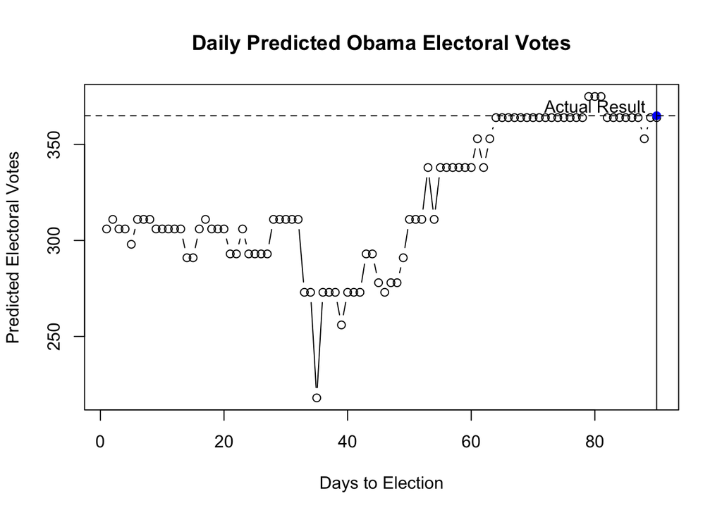

```r
DaystoElections08 <- as.Date("2008-11-04") -90
elections08$win_Obama <- ifelse(elections08$PriceD> elections08$PriceR, 1, 0)
Obama.dailypredEV08 <- rep(NA, 90)
for (i in 1:90) {
  daily.data <- subset(elections08, subset = (as.Date(elections08$day) == DaystoElections08 + i))
  Obama.dailypredEV08[i] <-sum(daily.data$EV[daily.data$win_Obama > 0])
}

plot(1:90, Obama.dailypredEV08, type = "b",
     main = "Daily Predicted Obama Electoral Votes",
     xlab = "Days to Election", ylab = "Predicted Electoral Votes")
points(90, 365, pch =19, col = "blue")
abline(v =90)
abline(h= 365, lty = "dashed")
text (80, 370, "Actual Result")
```

Closer to the Election Day the predicted electoral votes were accurately showing that Obama will win.

## Question 3

Repeat the previous exercise but this time use the seven-day *moving-average* price, instead of the daily price, for each candidate within a state. This can be done with a loop. For a given day, we take the average of the Session Close prices within the past seven days (including that day). To answer this question, we must first compute the seven-day average within each state. Next, we sum the electoral votes for the states Obama is predicted to win. Using the `tapply` function will allow us to efficiently compute the predicted winner for each state on a given day.

## Answer 3

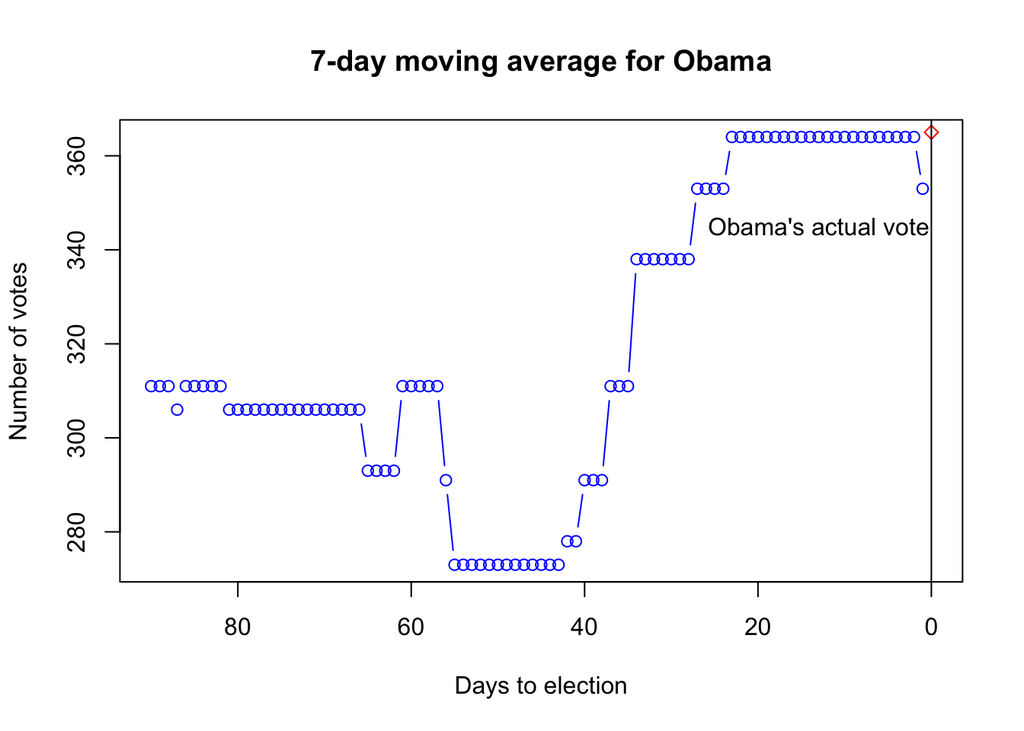

```r
elections08 <- merge(pres08, intrade08, by ="state")
DaystoElections08 <- as.Date("2008-11-04") -90
window <- 7
obama_votes <- c()
for(i in 1:90)
{
  dframe <- subset(elections08, subset = ((as.Date(day) > DaystoElections08 + i - window) &
                                            (as.Date(day) <= DaystoElections08 + i)))
  m_priceD <- tapply(dframe$PriceD, dframe$state, mean)
  m_priceR <- tapply(dframe$PriceR, dframe$state, mean)
  all_states <- data.frame(m_priceD, m_priceR)
  obama_states <- rownames(subset(all_states, subset = (m_priceD > m_priceR)))
  dframe <- subset(dframe, subset = (day == DaystoElections08 + i))
  obama_votes[i] <- sum(dframe[dframe$state %in% obama_states, 'EV'])
}

plot(90:1, obama_votes, type = "b", xlim = c(90, 0), col = "blue",
     main = "7-day moving average for Obama", xlab = "Days to election", ylab = "Number of votes")
points(0, 365, pch = 23, col = "red")
abline(v = 0)
text(13, 345, "Obama's actual vote")
```

The weekly moving average provides more reliable information forecasting Obama to win.

## Question 4

Create a similar plot for 2008 state-wide poll predictions using the data file `polls08.csv`. Notice that polls are not conducted daily within each state. Therefore, within a given state for each of the last 90 days of the campaign, we compute the average margin of victory from the most recent poll(s) conducted. If multiple polls occurred on the same day, average these polls. Based on the most recent predictions in each state, sum Obama’s total number of predicted electoral votes. One strategy to answer this question is to program two loops - an inner loop with 51 iterations for each state and an outer loop with 90 iterations for each day.

## Answer 4

```r
polls08 <- read.csv("polls08.csv")
polpres <- merge(polls08, pres08, by ="state")
polpres$margin <- polpres$Obama.x - polpres$McCain.x
polpres$DaystoElections08 <- as.Date("2008-11-04") - as.Date (polpres$middate)
Obama.pols <- rep (NA, 90)
state_names <- unique(polpres$state)
for (i in 1:90) {
  counter <- 0
  near.data <- subset(polpres, subset = (DaystoElections08 >= i))
  for (j in 1:51) {
    state_data <- subset(near.data, subset =(state== state_names[j]))
    state_data <- subset(state_data, subset =(DaystoElections08== min(state_data$DaystoElections08) ) )
    if(mean(state_data$margin) > 0) {
      counter = counter + mean(state_data$EV)
  }
  }
  Obama.pols[i] = counter
}
```

## Question 5

What is the relationship between the price margins of the Intrade market and the actual margin of victory? Using only the market data from the day before the election in 2008, regress Obama’s actual margin of victory in each state on Obama’s price margin from the Intrade markets. Similarly, in a separate analysis, regress Obama’s actual margin of victory on the Obama’s predicted margin from the latest polls within each state. Interpret the results of these regressions.

```r
elections08_dbefore$PriceD_margin <- elections08_dbefore$PriceD - elections08_dbefore$PriceR
dframe$obm_mcc_margin <-dframe$Obama - dframe$McCain
lm (dframe$obm_mcc ~ elections08_dbefore$PriceD_margin)
```

```
##
## Call:
## lm(formula = dframe$obm_mcc ~ elections08_dbefore$PriceD_margin)
##
## Coefficients:
##                       (Intercept)  elections08_dbefore$PriceD_margin
##                            1.3027                             0.2291
```

```r
pol_data08<- data.frame(state = c(), Pollster = c(), Obama.x = c(), McCain.x = c(), middate = c(),
                        state.name = c(), Obama.y = c(), McCain.y = c(), EV = c(), margin = c(), DaystoElections08 = c())

for (k in 1:51) {
    pol_data <- subset(polpres, subset =(state== state_names[k]))
    pol_data <- subset(pol_data, subset =(DaystoElections08== min(pol_data$DaystoElections08) ) )
    pol_data08 = rbind(pol_data08, pol_data)
}
pol_data08 <- pol_data08[, c("state", "margin")]
pol_data_clean <- data.frame(state = state_names, margin = tapply(pol_data08$margin, pol_data08$state, mean))
poll_pred08<- merge(pol_data_clean, dframe, by = "state")
summary(lm (obm_mcc_margin ~ margin, data = poll_pred08))
```

```
##
## Call:
## lm(formula = obm_mcc_margin ~ margin, data = poll_pred08)
##
## Residuals:
##      Min       1Q   Median       3Q      Max
## -16.3834  -2.7205   0.3556   3.4224  13.0111
##
## Coefficients:
##             Estimate Std. Error t value Pr(>|t|)
## (Intercept)  0.70908    0.78695   0.901    0.372
## margin       1.10856    0.04063  27.285   <2e-16 ***
## ---
## Signif. codes:  0 '***' 0.001 '**' 0.01 '*' 0.05 '.' 0.1 ' ' 1
##
## Residual standard error: 5.54 on 49 degrees of freedom
## Multiple R-squared:  0.9382, Adjusted R-squared:  0.937
## F-statistic: 744.5 on 1 and 49 DF,  p-value: < 2.2e-16
```

There is a very little positive relationship between increase in closing prices for Democratic nominee and actual victory of Obama. Meaning that with if there is 10% increase in the price in the market there are about 2 - 2.3 more people are voting for Obama. The margin coefficient of Obama winning in 2008 is 1,11.

## Question 6

Do the 2008 predictions of polls and Intrade accurately predict each state’s 2012 elections results? Using the fitted regressions from the previous question, forecast Obama’s actual margin of victory for the 2012 election in two ways. First, use the 2012 Intrade price margins from the day before the election as the predictor in each state. Recall that the 2012 Intrade data do not contain market prices for all states. Ignore states without data. Second, use the 2012 poll predicted margins from the latest polls in each state as the predictor, found in `polls12.csv`.

```r
polls12 <- read.csv("polls12.csv")
elections12_dbefore$Obama_margin_12 <- elections12_dbefore$Obama - elections12_dbefore$Romney
elections12_dbefore$PriceD_margin_12 <- elections12_dbefore$PriceD - elections12_dbefore$PriceR
elections12_dbefore$pres_pred_12 <- (elections12_dbefore$PriceD_margin_12* 0.2291) + 1.3027
elections12_dbefore$forecast_error <- elections12_dbefore$pres_pred_12 - elections12_dbefore$Obama_margin_12
polls12$DaystoElections12 <- as.Date("2012-11-06") - as.Date(polls12$middate)
pol_pres_last <- data.frame(state = c(), Obama =c(), Romney =c(), Pollster =c(), middate = c(),DaystoElections12 =c())
for (l in 1:51) {
    pol_pres12 <- subset(polls12, subset =(state== state_names[l]))
    pol_pres12 <- subset(pol_pres12, subset =(DaystoElections12== min(DaystoElections12) ) )
    pol_pres_last = rbind(pol_pres_last, pol_pres12)
}
pol_pres_last$poll12_margin <- pol_pres_last$Obama - pol_pres_last$Romney
pol_pres_last <- pol_pres_last[, c("state", "poll12_margin")]
pol_pres_last_clean <- data.frame(margin = tapply(pol_pres_last$poll12_margin, pol_pres_last$state, mean))
pol_pres_last_clean <- cbind(state = rownames(pol_pres_last_clean), pol_pres_last_clean)
poll_pred12<- merge(pol_pres_last_clean, elections12_dbefore[,c("state", "Obama_margin_12")], by = "state")
poll_pred12$forecast <- (poll_pred12$margin* 1.1)+0.7
poll_pred12$forecast_error <- poll_pred12$forecast - poll_pred12$margin
```